# Analyse des Communautées d’amphibiens - Maîtrise en biologie

## Probabilité de présence de toutes les espèces étudiées selon les valeurs de l’habitat.

L’analyse précédente a permis d’émettre un graphique qui prédit la probabilité de présence des ambystomes selon les valeurs environnementales les plus importantes pour les modèles. Ce graphique représente un outil intéressant pour la conservation des amphibiens lors d’exploitation forestière. Le valeur environnementale la plus importante pour chaque espèce d’amphibien étudiée sera déterminé par AICc et deux graphiques seront générés pour illustrer les résultats: un graphique pour prédire leur présence selon la/les valeur/s la/les plus importante/s pour l’espèce et un graphique de prédiction de présence selon l’ouverture de la cannopée et l’hydrologie pour être comparable avec le 2iem graphique produit pour les ambystomes.

### Grenouille des bois (LISY)

1. **Vérification des données**

```r
library(car)
LYmod_test <- glm(LISY ~ Ouverture + Hydro + Debris_out +X +Y ,family = binomial, data=df) #puisque les conditions environnementales sont liées au Traitement, on retire traitement
vif(LYmod_test) #X et Y sont corrélés, makes sence
```

```
               GVIF Df GVIF^(1/(2*Df))
Ouverture  2.206077  1        1.485287
Hydro      1.202555  1        1.096611
Debris_out 1.789679  2        1.156628
X          5.263089  1        2.294142
Y          5.911082  1        2.431272
```

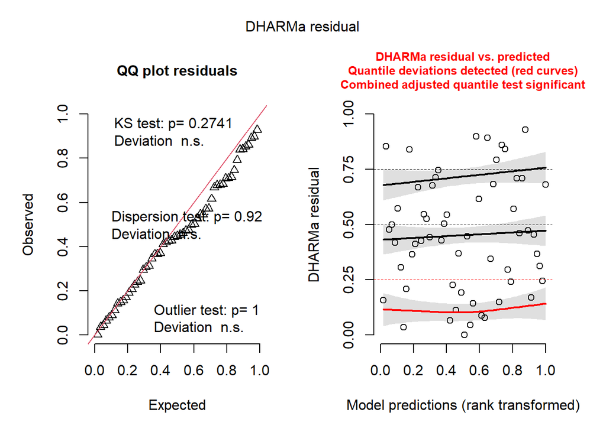

```r
res <- simulateResiduals(LYmod_test) #validation du modèle corrigé
plot(res)
```

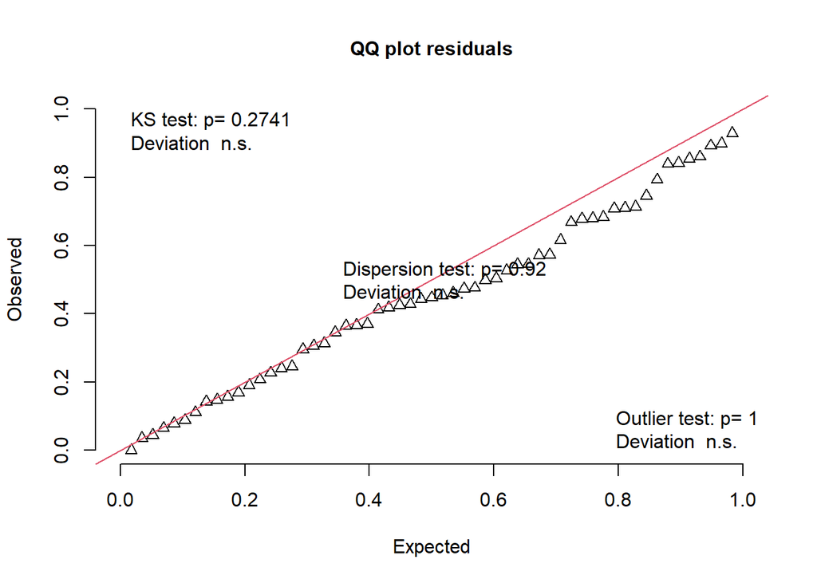

```
    Exact one-sample Kolmogorov-Smirnov test

data:  simulationOutput$scaledResiduals
D = 0.12907, p-value = 0.2741
alternative hypothesis: two-sided
```

```r
testUniformity(res) #uniformité des résidus (p-value plus de 0.05) Good!
```

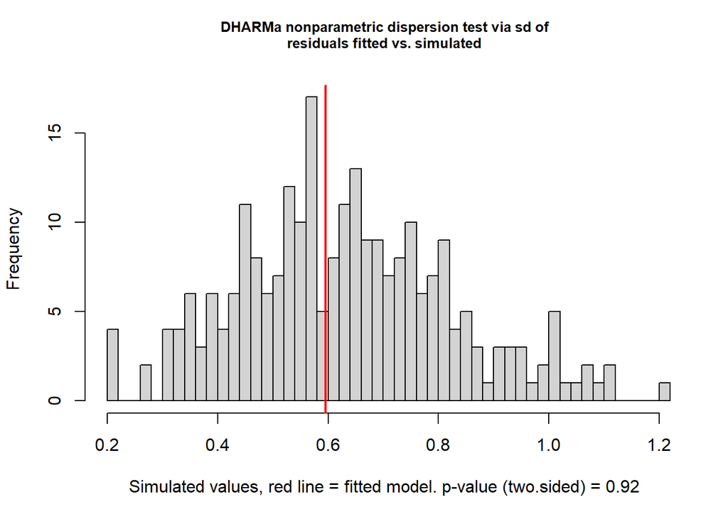

```
    DHARMa nonparametric dispersion test via sd of residuals fitted vs.
    simulated

data:  simulationOutput
dispersion = 0.94322, p-value = 0.92
alternative hypothesis: two.sided
```

```r
testDispersion(res) #Pas de surdispersion (p-value plus de 0.05) Good!
```

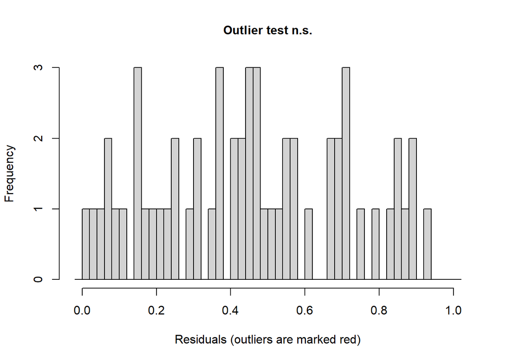

```
    DHARMa bootstrapped outlier test

data:  res
outliers at both margin(s) = 0, observations = 57, p-value = 1
alternative hypothesis: two.sided
 percent confidence interval:
 0.00000000 0.01754386
sample estimates:
outlier frequency (expected: 0.000701754385964912 )
                                                  0
```

```r
testOutliers(res) #0 Outliers, Good!
```

2. **Création des modèles pour l’AICc**

   ```r
   #Modèle nul
   LYmod0 <- glm(LISY ~ 1, family = binomial, data = df)

   #Modèle avec juste canopée
   LYmod_can <- glm(LISY ~ Ouverture+X+Y,family = binomial,data = df)
   summary(LYmod_can)
   res2 <- simulateResiduals(LYmod_can)
   testUniformity(res2) #uniformité des résidus (p-value plus de 0.05) Good!
   ```

   ```r
   testDispersion(res2) #Pas de surdispersion (p-value plus de 0.05) Good!
   ```

   ```r
   testOutliers(res2) #Zéro Outliers, good!
   ```

   ```r
   #Modèle avec juste hydro
   LYmod_hydro <- glm(LISY ~ Hydro+X+Y,family = binomial,data = df)
   summary(LYmod_hydro)
   res3 <- simulateResiduals(LYmod_hydro)
   testUniformity(res3) #uniformité des résidus (p-value plus de 0.05) Good!
   ```

   ```r
   testDispersion(res3) #Pas de surdispersion (p-value plus de 0.05) Good!
   ```

   ```r
   testOutliers(res3) #Zéro Outliers, good!
   ```

   ```r
   #Modèle avec juste débris
   LYmod_debris <- glm(LISY ~ Debris_out+X+Y,family = binomial,data = df)
   res4 <- simulateResiduals(LYmod_debris)
   testUniformity(res4) #uniformité des résidus (p-value plus de 0.05) Good!
   ```

   ```r
   testDispersion(res4) #Pas de surdispersion (p-value plus de 0.05) Good!
   ```

   ```r
   testOutliers(res4) #Zéro Outliers, good!
   ```

   ```r
   #Modèle Ouverture+Débris
   LYmod_can_deb <- glm(LISY ~ Ouverture+Debris_out+X+Y,family = binomial,data = df)
   res5 <- simulateResiduals(LYmod_can_deb)
   testUniformity(res5) #uniformité des résidus (p-value plus de 0.05) Good!
   ```

   ```r
   testDispersion(res5) #Pas de surdispersion (p-value plus de 0.05) Good!
   ```

   ```r
   testOutliers(res5) #Zéro Outliers, good!
   ```

   ```r
   #Modèle Ouverture+Hydro
   LYmod_can_hydro <- glm(LISY ~ Ouverture+Hydro+X+Y,family = binomial,data = df)
   res6 <- simulateResiduals(LYmod_can_hydro)
   testUniformity(res6) #uniformité des résidus (p-value plus de 0.05) Good!
   ```

   ```r
   testDispersion(res6) #Pas de surdispersion (p-value plus de 0.05) Good!
   ```

   ```r
   testOutliers(res6) #Zéro Outliers, good!
   ```

   ```r
   #Modèle Hydro+débris
   LYmod_hydro_deb <- glm(LISY ~ Debris_out+Hydro+X+Y,family = binomial,data = df)
   res7 <- simulateResiduals(LYmod_hydro_deb)
   testUniformity(res7) #uniformité des résidus (p-value plus de 0.05) Good!
   ```

   ```r
   testDispersion(res7) #Pas de surdispersion (p-value plus de 0.05) Good!
   ```

   ```r
   testOutliers(res7) #Zéro Outliers, good!
   ```

3. **Analyse de l’AICc**

   ```r
   AICc_tab <- AICc(LYmod0, LYmod_can, LYmod_hydro, LYmod_debris, LYmod_can_deb, LYmod_can_hydro, LYmod_hydro_deb, LYmod_test)
   AICc_tab$Delta_AICc <- AICc_tab$AICc - min(AICc_tab$AICc)
   AICc_tab$Poids <- exp(-0.5 * AICc_tab$Delta_AICc) / sum(exp(-0.5 * AICc_tab$Delta_AICc))
   AICc_tab #LYmod_hydro et LYmod_can_hydro ont un poid nettement plus élevé.
   ```

   ```
                   df     AICc Delta_AICc       Poids
   LYmod0           1 44.53553  8.0068677 0.007961363
   LYmod_can        4 42.17991  5.6512531 0.025852505
   LYmod_hydro      4 36.52866  0.0000000 0.436170860
   LYmod_debris     5 45.83177  9.3031100 0.004164012
   LYmod_can_deb    6 45.43850  8.9098431 0.005068842
   LYmod_can_hydro  5 36.67032  0.1416559 0.406346432
   LYmod_hydro_deb  6 40.00660  3.4779345 0.076635988
   LYmod_test       7 41.42011  4.8914501 0.037799997
   ```

   ```r
   summary(LYmod_can_hydro)
   ```

   ```
   Call:
   glm(formula = LISY ~ Ouverture + Hydro + X + Y, family = binomial,
       data = df)

   Coefficients:
                 Estimate Std. Error z value Pr(>|z|)
   (Intercept)  2.616e+02  3.018e+02   0.867   0.3860
   Ouverture    3.109e-02  2.310e-02   1.346   0.1782
   Hydrosec    -3.154e+00  1.290e+00  -2.445   0.0145 *
   X            3.095e-05  2.809e-05   1.102   0.2705
   Y           -5.266e-05  6.075e-05  -0.867   0.3861
   ---
   Signif. codes:  0 '***' 0.001 '**' 0.01 '*' 0.05 '.' 0.1 ' ' 1

   (Dispersion parameter for binomial family taken to be 1)

       Null deviance: 42.463  on 56  degrees of freedom
   Residual deviance: 25.494  on 52  degrees of freedom
   AIC: 35.494

   Number of Fisher Scoring iterations: 7
   ```

   ```r
   summary(LYmod_hydro)
   ```

   ```
   Call:
   glm(formula = LISY ~ Hydro + X + Y, family = binomial, data = df)

   Coefficients:
                 Estimate Std. Error z value Pr(>|z|)
   (Intercept)  1.090e+02  2.780e+02   0.392  0.69508
   Hydrosec    -3.597e+00  1.283e+00  -2.804  0.00505 **
   X            2.832e-05  2.769e-05   1.023  0.30631
   Y           -2.210e-05  5.605e-05  -0.394  0.69334
   ---
   Signif. codes:  0 '***' 0.001 '**' 0.01 '*' 0.05 '.' 0.1 ' ' 1

   (Dispersion parameter for binomial family taken to be 1)

       Null deviance: 42.463  on 56  degrees of freedom
   Residual deviance: 27.759  on 53  degrees of freedom
   AIC: 35.759

   Number of Fisher Scoring iterations: 6
   ```

Ici, l’hydrologie semble être le meilleur prédicteur pour la présence de la grenouille des bois

4. **Visuels**

   Prédiction de la présence en se fiant que sur l’hydrologie

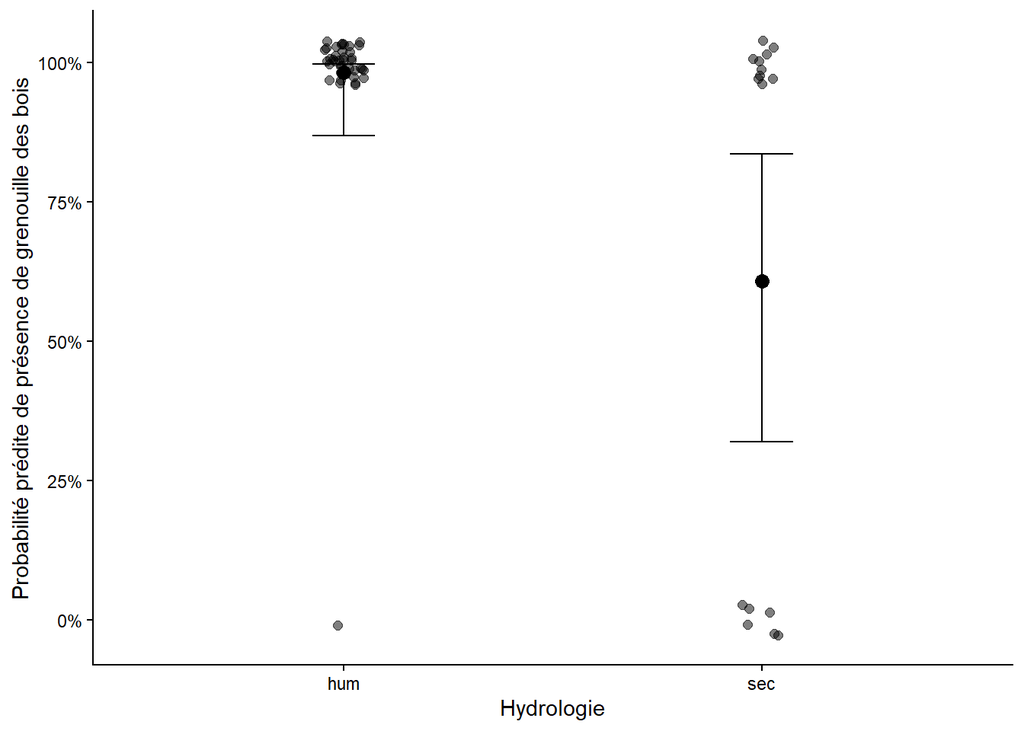

   ```r
   pred_LISY <- ggpredict(LYmod_hydro, terms = "Hydro")
   set.seed(123)
   ggplot(df, aes(x = Hydro, y = LISY)) +
   geom_jitter(width = 0.05,height = 0.04,alpha = 0.5,size = 2) +
   geom_errorbar(data = pred_LISY, aes(x=x, ymin = conf.low, ymax = conf.high),width = 0.15,inherit.aes = FALSE) +
   geom_point(data = pred_LISY,aes(x = x,y = predicted),size = 3, inherit.aes = FALSE) +
   scale_y_continuous(labels = scales::percent) +
   labs(x = "Hydrologie",y = "Probabilité prédite de présence de grenouille des bois") +
   theme_classic()
   ```

Prédiction de la présence en se fiant sur l’ouverture de la canopée et l’hydrologie

```r
pred_LISY <- ggpredict(LYmod_can_hydro,terms = c("Ouverture", "Hydro"))
```

```
Data were 'prettified'. Consider using `terms="Ouverture [all]"` to get
  smooth plots.
```

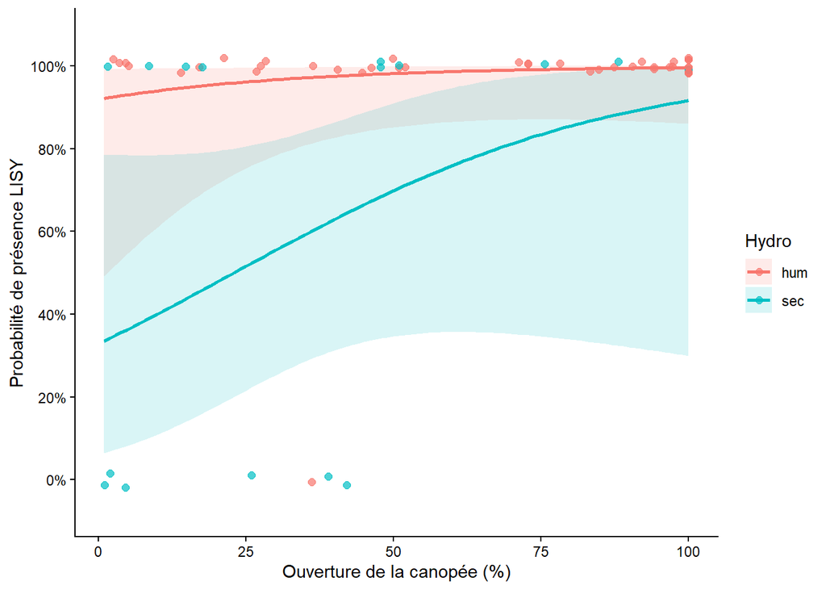

```r
set.seed(123)
ggplot(pred_LISY, aes(x = x, y = predicted, colour = group)) +
  # Intervalle de confiance
  geom_ribbon(aes(ymin = conf.low, ymax = conf.high, fill = group),alpha = 0.15,colour = NA) +
  # Courbes prédites
  geom_line(linewidth = 1) +
  # Observations réelles
  geom_jitter(data = df,aes(x = Ouverture, y = LISY, colour = Hydro),width = 0,height = 0.02,alpha = 0.7,size = 2) +
  scale_y_continuous(limits = c(-0.08, 1.08),breaks = seq(0, 1, 0.2),labels = function(x) paste0(x * 100, "%")) +
  labs(x = "Ouverture de la canopée (%)",y = "Probabilité de présence LISY",colour = "Hydro",fill = "Hydro") +
  theme_classic()
```

Comparé à ce qui était attendu dans la littérature, la grenouille des bois semble plus associée avec de longues hydropériodes dans mon étude.

### Grenouille verte (LICL):

1. **Vérification des données :**

```r
LLmod_test <- glm(LICL ~ Ouverture + Hydro + Debris_out +X +Y ,family = binomial, data=df) #puisque les conditions environnementales sont liées au Traitement, on retire traitement
vif(LLmod_test) #X et Y sont corrélés, makes sence
```

```
                GVIF Df GVIF^(1/(2*Df))
Ouverture   2.246710  1        1.498903
Hydro       1.135963  1        1.065816
Debris_out  2.382163  2        1.242347
X          15.878286  1        3.984757
Y          15.072994  1        3.882395
```

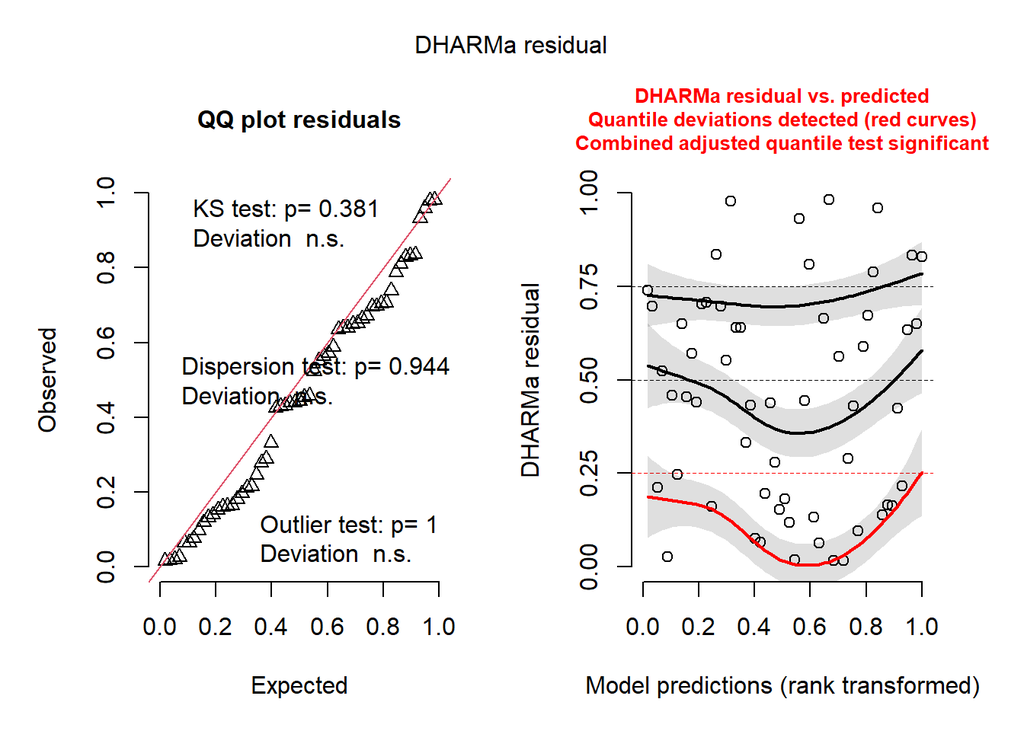

```r
res <- simulateResiduals(LLmod_test) #validation du modèle corrigé
plot(res)
```

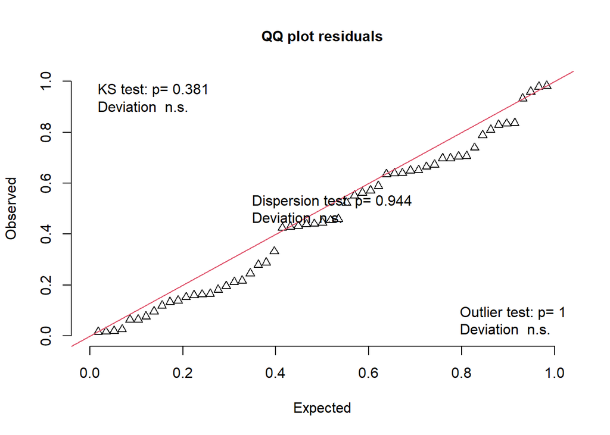

```
    Exact one-sample Kolmogorov-Smirnov test

data:  simulationOutput$scaledResiduals
D = 0.11751, p-value = 0.381
alternative hypothesis: two-sided
```

```r
testUniformity(res) #uniformité des résidus (p-value plus de 0.05) Good!
```

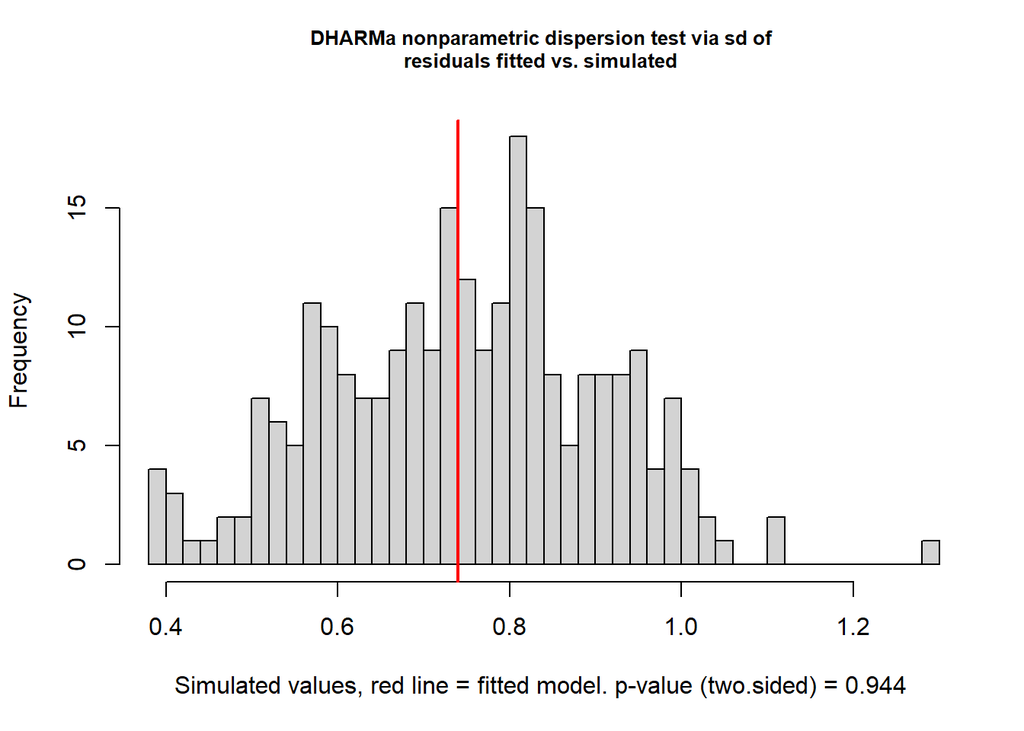

```
    DHARMa nonparametric dispersion test via sd of residuals fitted vs.
    simulated

data:  simulationOutput
dispersion = 0.99055, p-value = 0.944
alternative hypothesis: two.sided
```

```r
testDispersion(res) #Pas de surdispersion (p-value plus de 0.05) Good!
```

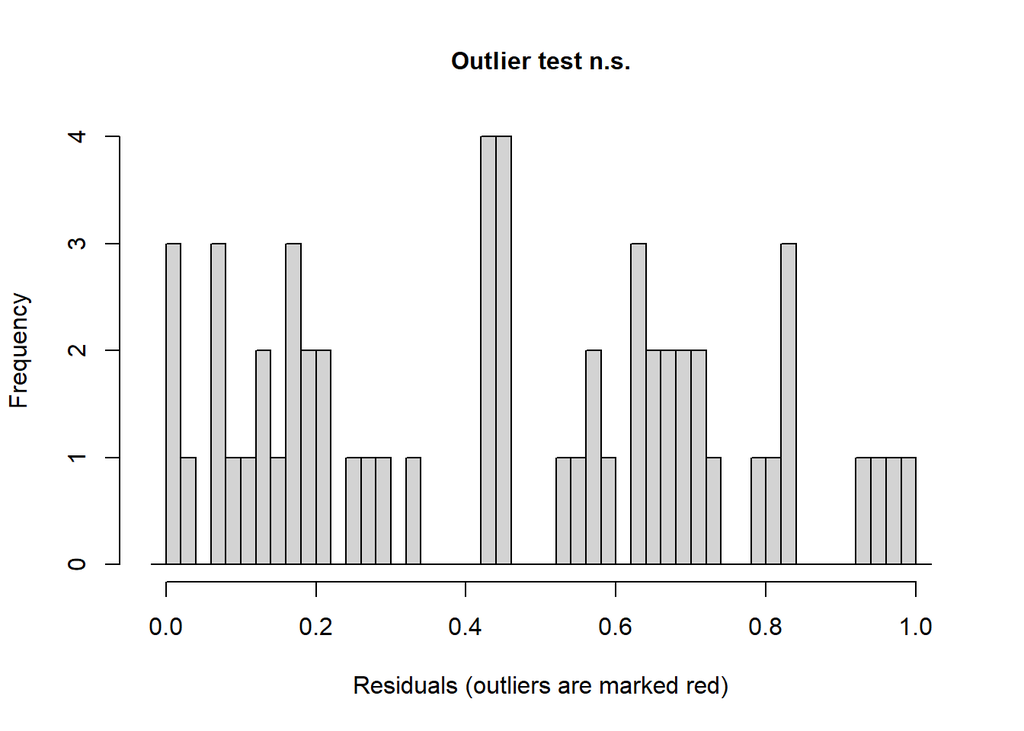

```
    DHARMa bootstrapped outlier test

data:  res
outliers at both margin(s) = 0, observations = 57, p-value = 1
alternative hypothesis: two.sided
 percent confidence interval:
 0.000000000 0.009210526
sample estimates:
outlier frequency (expected: 0.000526315789473684 )
                                                  0
```

```r
testOutliers(res) #0 Outliers, Good!
```

2. **Création des modèles pour l’AICc**

   ```r
   #Modèle nul
   LLmod0 <- glm(LICL ~ 1, family = binomial, data = df)

   #Modèle avec juste canopée
   LLmod_can <- glm(LICL ~ Ouverture+X+Y,family = binomial,data = df)
   res2 <- simulateResiduals(LLmod_can)
   testUniformity(res2) #uniformité des résidus (p-value plus de 0.05) Good!
   ```

   ```r
   testDispersion(res2) #Pas de surdispersion (p-value plus de 0.05) Good!
   ```

   ```r
   testOutliers(res2) #Zéro Outliers, good!
   ```

   ```r
   #Modèle avec juste hydro
   LLmod_hydro <- glm(LICL ~ Hydro+X+Y,family = binomial,data = df)
   res3 <- simulateResiduals(LLmod_hydro)
   testUniformity(res3) #uniformité des résidus (p-value plus de 0.05) Good!
   ```

   ```r
   testDispersion(res3) #Pas de surdispersion (p-value plus de 0.05) Good!
   ```

   ```r
   testOutliers(res3) #Zéro Outliers, good!
   ```

   ```r
   #Modèle avec juste débris
   LLmod_debris <- glm(LICL ~ Debris_out+X+Y,family = binomial,data = df)
   res4 <- simulateResiduals(LLmod_debris)
   testUniformity(res4) #uniformité des résidus (p-value plus de 0.05) Good!
   ```

   ```r
   testDispersion(res4) #Pas de surdispersion (p-value plus de 0.05) Good!
   ```

   ```r
   testOutliers(res4) #Zéro Outliers, good!
   ```

   ```r
   #Modèle Ouverture+Débris
   LLmod_can_deb <- glm(LICL ~ Ouverture+Debris_out+X+Y,family = binomial,data = df)
   res5 <- simulateResiduals(LLmod_can_deb)
   testUniformity(res5) #uniformité des résidus (p-value plus de 0.05) Good!
   ```

   ```r
   testDispersion(res5) #Pas de surdispersion (p-value plus de 0.05) Good!
   ```

   ```r
   testOutliers(res5) #Zéro Outliers, good!
   ```

   ```r
   #Modèle Ouverture+Hydro
   LLmod_can_hydro <- glm(LICL ~ Ouverture+Hydro+X+Y,family = binomial,data = df)
   res6 <- simulateResiduals(LLmod_can_hydro)
   testUniformity(res6) #uniformité des résidus (p-value plus de 0.05) Good!
   ```

   ```r
   testDispersion(res6) #Pas de surdispersion (p-value plus de 0.05) Good!
   ```

   ```r
   testOutliers(res6) #Zéro Outliers, good!
   ```

   ```r
   #Modèle Hydro+débris
   LLmod_hydro_deb <- glm(LICL ~ Debris_out+Hydro+X+Y,family = binomial,data = df)
   res7 <- simulateResiduals(LLmod_hydro_deb)
   testUniformity(res7) #uniformité des résidus (p-value plus de 0.05) Good!
   ```

   ```r
   testDispersion(res7) #Pas de surdispersion (p-value plus de 0.05) Good!
   ```

   ```r
   testOutliers(res7) #Zéro Outliers, good!
   ```

3. **Analyse AICc**

   ```r
   AICc_tab <- AICc(LLmod0, LLmod_can, LLmod_hydro, LLmod_debris, LLmod_can_deb, LLmod_can_hydro, LLmod_hydro_deb, LLmod_test)
   AICc_tab$Delta_AICc <- AICc_tab$AICc - min(AICc_tab$AICc)
   AICc_tab$Poids <- exp(-0.5 * AICc_tab$Delta_AICc) / sum(exp(-0.5 * AICc_tab$Delta_AICc))
   AICc_tab #LLmod_can, LLmod_can_hydro et LLmod_can_deb sont les meilleurs
   ```

   ```
                   df     AICc Delta_AICc      Poids
   LLmod0           1 55.01500   4.103192 0.04646774
   LLmod_can        4 50.91180   0.000000 0.36153338
   LLmod_hydro      4 52.79655   1.884743 0.14089049
   LLmod_debris     5 56.46356   5.551758 0.02252162
   LLmod_can_deb    6 52.76124   1.849441 0.14339940
   LLmod_can_hydro  5 51.93948   1.027676 0.21626756
   LLmod_hydro_deb  6 57.59265   6.680849 0.01280621
   LLmod_test       7 54.63776   3.725952 0.05611360
   ```

   ```r
   summary(LLmod_can_hydro)
   ```

   ```
   Call:
   glm(formula = LICL ~ Ouverture + Hydro + X + Y, family = binomial,
       data = df)

   Coefficients:
                 Estimate Std. Error z value Pr(>|z|)
   (Intercept) -1.613e+02  6.086e+02  -0.265    0.791
   Ouverture    2.366e-02  1.438e-02   1.645    0.100 .
   Hydrosec    -1.260e+00  1.175e+00  -1.072    0.284
   X            1.568e-05  4.927e-05   0.318    0.750
   Y            3.041e-05  1.224e-04   0.248    0.804
   ---
   Signif. codes:  0 '***' 0.001 '**' 0.01 '*' 0.05 '.' 0.1 ' ' 1

   (Dispersion parameter for binomial family taken to be 1)

       Null deviance: 52.942  on 56  degrees of freedom
   Residual deviance: 40.763  on 52  degrees of freedom
   AIC: 50.763

   Number of Fisher Scoring iterations: 6
   ```

   ```r
   summary(LLmod_can) #ouverture est proche d'être significatif
   ```

   ```
   Call:
   glm(formula = LICL ~ Ouverture + X + Y, family = binomial, data = df)

   Coefficients:
                 Estimate Std. Error z value Pr(>|z|)
   (Intercept) -2.193e+02  5.887e+02  -0.373   0.7095
   Ouverture    2.562e-02  1.463e-02   1.751   0.0799 .
   X            9.149e-06  4.790e-05   0.191   0.8485
   Y            4.211e-05  1.185e-04   0.356   0.7222
   ---
   Signif. codes:  0 '***' 0.001 '**' 0.01 '*' 0.05 '.' 0.1 ' ' 1

   (Dispersion parameter for binomial family taken to be 1)

       Null deviance: 52.942  on 56  degrees of freedom
   Residual deviance: 42.143  on 53  degrees of freedom
   AIC: 50.143

   Number of Fisher Scoring iterations: 6
   ```

   ```r
   summary(LLmod_can_deb) #Ouverture significatif
   ```

   ```
   Call:
   glm(formula = LICL ~ Ouverture + Debris_out + X + Y, family = binomial,
       data = df)

   Coefficients:
                  Estimate Std. Error z value Pr(>|z|)
   (Intercept)  -2.904e+02  6.352e+02  -0.457   0.6475
   Ouverture     4.465e-02  2.161e-02   2.066   0.0389 *
   Debris_out.L -7.324e-01  7.721e-01  -0.948   0.3429
   Debris_out.Q -1.280e+00  9.525e-01  -1.344   0.1790
   X             9.704e-06  5.184e-05   0.187   0.8515
   Y             5.582e-05  1.278e-04   0.437   0.6623
   ---
   Signif. codes:  0 '***' 0.001 '**' 0.01 '*' 0.05 '.' 0.1 ' ' 1

   (Dispersion parameter for binomial family taken to be 1)

       Null deviance: 52.942  on 56  degrees of freedom
   Residual deviance: 39.081  on 51  degrees of freedom
   AIC: 51.081

   Number of Fisher Scoring iterations: 6
   ```

   ```r
   summary(LLmod_hydro)
   ```

   ```
   Call:
   glm(formula = LICL ~ Hydro + X + Y, family = binomial, data = df)

   Coefficients:
                 Estimate Std. Error z value Pr(>|z|)
   (Intercept) -4.518e+02  5.817e+02  -0.777    0.437
   Hydrosec    -1.393e+00  1.143e+00  -1.219    0.223
   X           -7.386e-06  4.508e-05  -0.164    0.870
   Y            8.917e-05  1.169e-04   0.763    0.445

   (Dispersion parameter for binomial family taken to be 1)

       Null deviance: 52.942  on 56  degrees of freedom
   Residual deviance: 44.027  on 53  degrees of freedom
   AIC: 52.027

   Number of Fisher Scoring iterations: 6
   ```

Bien que ce ne soit pas aussi clair que les autres analyses, il semblerait que l’ouverture de la canopée joue un grand rôle sur la présence de la grenouille verte

4. **Visualisation**

   Que avec l’ouverture de la canopée:

   ```r
   pred_amby <- ggpredict(LLmod_can, terms = "Ouverture")
   ```

   ```
   Data were 'prettified'. Consider using `terms="Ouverture [all]"` to get
     smooth plots.
   ```

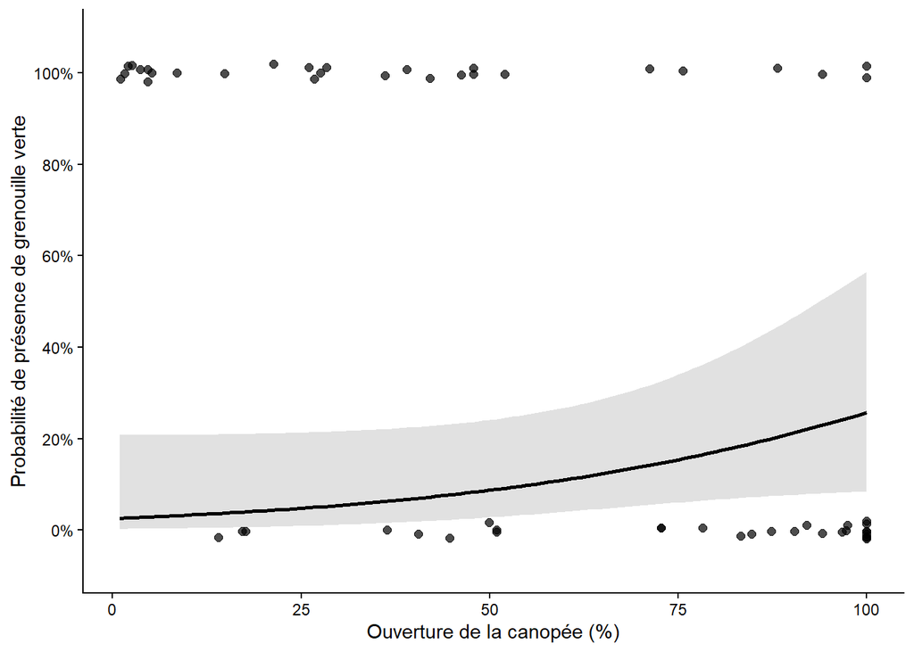

Avec l’ouverture de la canopée ET l’hydrologie:

```r
pred_LICL <- ggpredict(LLmod_can_hydro,terms = c("Ouverture", "Hydro"))
```

```
Data were 'prettified'. Consider using `terms="Ouverture [all]"` to get
  smooth plots.
```

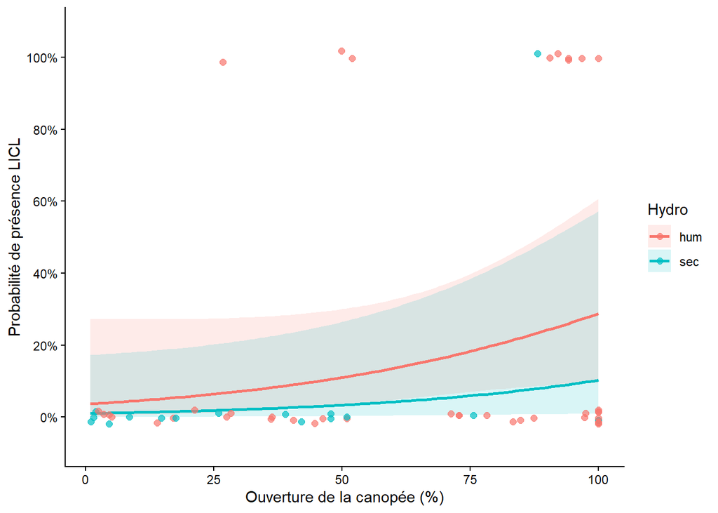

```r
set.seed(123)
ggplot(pred_LICL, aes(x = x, y = predicted, colour = group)) +
  # Intervalle de confiance
  geom_ribbon(aes(ymin = conf.low, ymax = conf.high, fill = group),alpha = 0.15,colour = NA) +
  # Courbes prédites
  geom_line(linewidth = 1) +
  # Observations réelles
  geom_jitter(data = df,aes(x = Ouverture, y = LICL, colour = Hydro),width = 0,height = 0.02,alpha = 0.7,size = 2) +
  scale_y_continuous(limits = c(-0.08, 1.08),breaks = seq(0, 1, 0.2),labels = function(x) paste0(x * 100, "%")) +
  labs(x = "Ouverture de la canopée (%)",y = "Probabilité de présence LICL",colour = "Hydro",fill = "Hydro") +
  theme_classic()
```

Comme prédit dans la littérature, la grenouille verte semble associée avec une canopée ouverte.

### Rainette crucifère (PSCR):

1. Vérification des données :

```r
PSmod_test <- glm(PSCR ~ Ouverture + Hydro + Debris_out +X +Y ,family = binomial, data=df) #puisque les conditions environnementales sont liées au Traitement, on retire traitement
vif(PSmod_test) #X et Y sont corrélés, makes sence
```

```
                GVIF Df GVIF^(1/(2*Df))
Ouverture   1.539535  1        1.240780
Hydro       2.133019  1        1.460486
Debris_out  1.479927  2        1.102961
X          10.572256  1        3.251501
Y          11.989178  1        3.462539
```

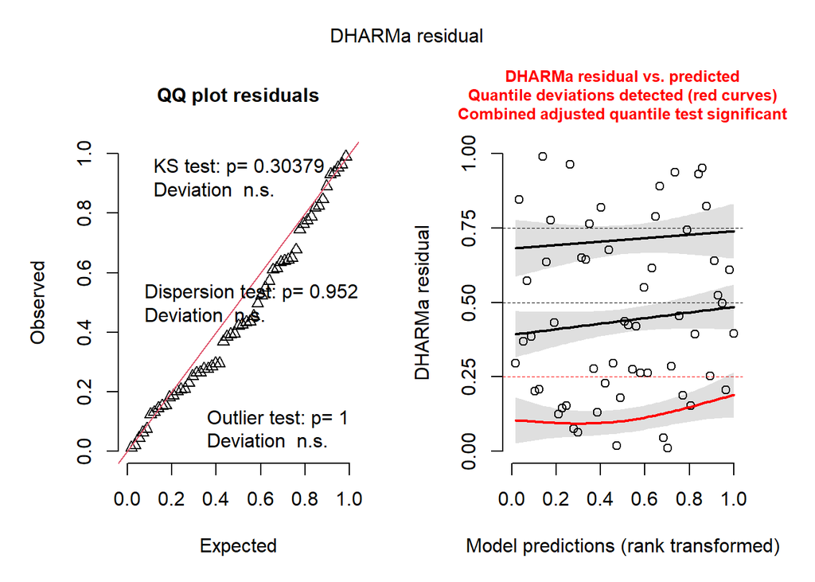

```r
res <- simulateResiduals(PSmod_test) #validation du modèle corrigé
plot(res)
```

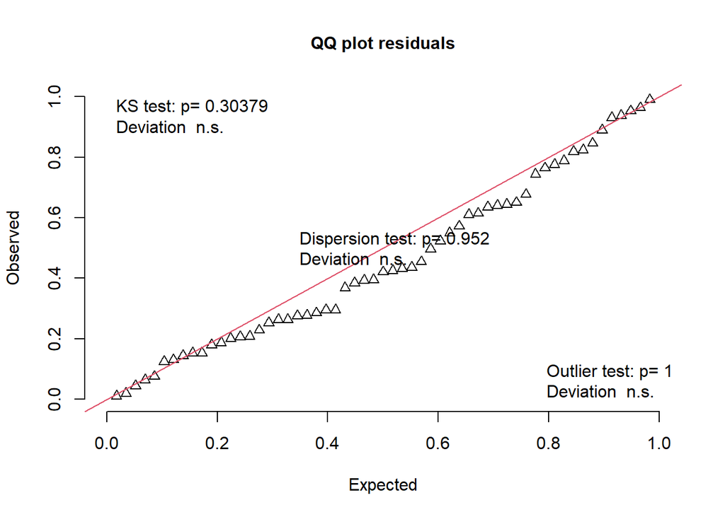

```
    Exact one-sample Kolmogorov-Smirnov test

data:  simulationOutput$scaledResiduals
D = 0.12559, p-value = 0.3038
alternative hypothesis: two-sided
```

```r
testUniformity(res) #uniformité des résidus (p-value plus de 0.05) Good!
```

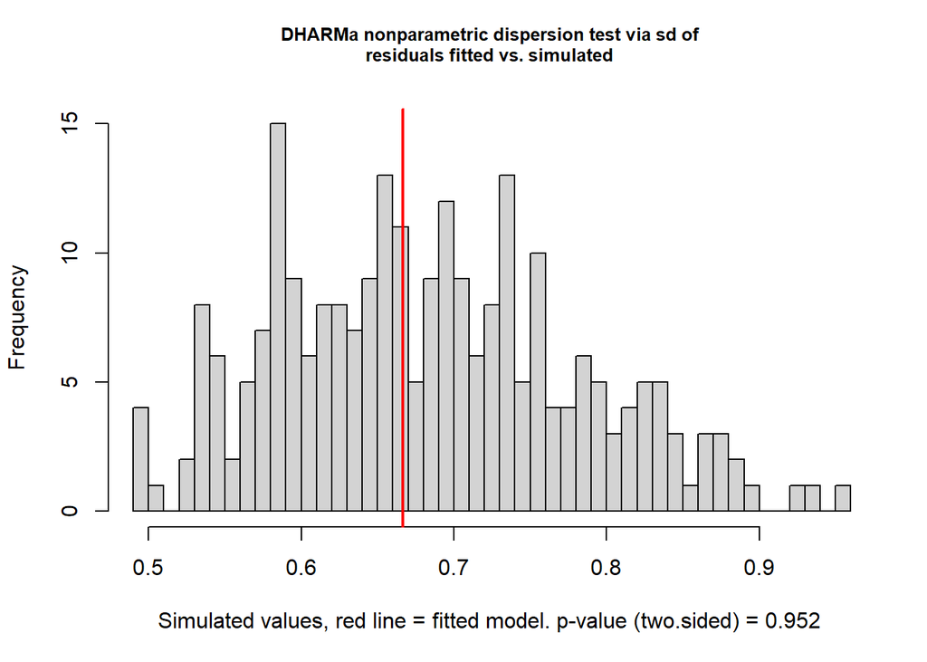

```
    DHARMa nonparametric dispersion test via sd of residuals fitted vs.
    simulated

data:  simulationOutput
dispersion = 0.97558, p-value = 0.952
alternative hypothesis: two.sided
```

```r
testDispersion(res) #Pas de surdispersion (p-value plus de 0.05) Good!
```

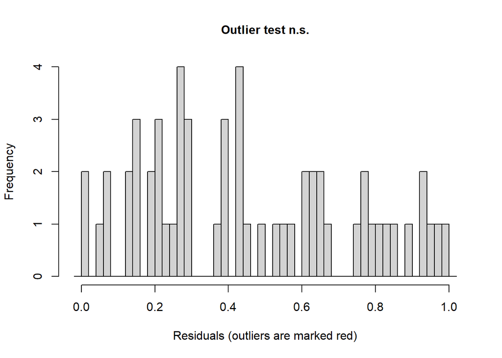

```
    DHARMa bootstrapped outlier test

data:  res
outliers at both margin(s) = 0, observations = 57, p-value = 1
alternative hypothesis: two.sided
 percent confidence interval:
 0 0
sample estimates:
outlier frequency (expected: 0.000350877192982456 )
                                                  0
```

```r
testOutliers(res) #0 Outliers, Good!
```

2. Création des modèles pour l’AICc

   ```r
   #Modèle nul
   PSmod0 <- glm(PSCR ~ 1, family = binomial, data = df)

   #Modèle avec juste canopée
   PSmod_can <- glm(PSCR ~ Ouverture+X+Y,family = binomial,data = df)
   res2 <- simulateResiduals(PSmod_can)
   testUniformity(res2) #uniformité des résidus (p-value plus de 0.05) Good!
   ```

   ```r
   testDispersion(res2) #Pas de surdispersion (p-value plus de 0.05) Good!
   ```

   ```r
   testOutliers(res2) #Zéro Outliers, good!
   ```

   ```r
   #Modèle avec juste hydro
   PSmod_hydro <- glm(PSCR ~ Hydro+X+Y,family = binomial,data = df)
   res3 <- simulateResiduals(PSmod_hydro)
   testUniformity(res3) #uniformité des résidus (p-value plus de 0.05) Good!
   ```

   ```r
   testDispersion(res3) #Pas de surdispersion (p-value plus de 0.05) Good!
   ```

   ```r
   testOutliers(res3) #Zéro Outliers, good!
   ```

   ```r
   #Modèle avec juste débris
   PSmod_debris <- glm(PSCR ~ Debris_out+X+Y,family = binomial,data = df)
   res4 <- simulateResiduals(PSmod_debris)
   testUniformity(res4) #uniformité des résidus (p-value plus de 0.05) Good!
   ```

   ```r
   testDispersion(res4) #Pas de surdispersion (p-value plus de 0.05) Good!
   ```

   ```r
   testOutliers(res4) #Zéro Outliers, good!
   ```

   ```r
   #Modèle Ouverture+Débris
   PSmod_can_deb <- glm(PSCR ~ Ouverture+Debris_out+X+Y,family = binomial,data = df)
   res5 <- simulateResiduals(PSmod_can_deb)
   testUniformity(res5) #uniformité des résidus (p-value plus de 0.05) Good!
   ```

   ```r
   testDispersion(res5) #Pas de surdispersion (p-value plus de 0.05) Good!
   ```

   ```r
   testOutliers(res5) #Zéro Outliers, good!
   ```

   ```r
   #Modèle Ouverture+Hydro
   PSmod_can_hydro <- glm(PSCR ~ Ouverture+Hydro+X+Y,family = binomial,data = df)
   res6 <- simulateResiduals(PSmod_can_hydro)
   testUniformity(res6) #uniformité des résidus (p-value plus de 0.05) Good!
   ```

   ```r
   testDispersion(res6) #Pas de surdispersion (p-value plus de 0.05) Good!
   ```

   ```r
   testOutliers(res6) #Zéro Outliers, good!
   ```

   ```r
   #Modèle Hydro+débris
   PSmod_hydro_deb <- glm(PSCR ~ Debris_out+Hydro+X+Y,family = binomial,data = df)
   res7 <- simulateResiduals(PSmod_hydro_deb)
   testUniformity(res7) #uniformité des résidus (p-value plus de 0.05) Good!
   ```

   ```r
   testDispersion(res7) #Pas de surdispersion (p-value plus de 0.05) Good!
   ```

   ```r
   testOutliers(res7) #Zéro Outliers, good!
   ```

3. **Analyse AICc**

   ```r
   AICc_tab <- AICc(PSmod0, PSmod_can, PSmod_hydro, PSmod_debris, PSmod_can_deb, PSmod_can_hydro, PSmod_hydro_deb, PSmod_test)
   AICc_tab$Delta_AICc <- AICc_tab$AICc - min(AICc_tab$AICc)
   AICc_tab$Poids <- exp(-0.5 * AICc_tab$Delta_AICc) / sum(exp(-0.5 * AICc_tab$Delta_AICc))
   AICc_tab #PSmod_hydro_deb est le meilleur
   ```

   ```
                   df     AICc Delta_AICc        Poids
   PSmod0           1 73.16938   8.121375 0.0098967547
   PSmod_can        4 79.56287  14.514869 0.0004047279
   PSmod_hydro      4 68.72558   3.677572 0.0912961400
   PSmod_debris     5 69.02286   3.974858 0.0786860278
   PSmod_can_deb    6 70.48267   5.434666 0.0379231426
   PSmod_can_hydro  5 71.05555   6.007544 0.0284777334
   PSmod_hydro_deb  6 65.04801   0.000000 0.5741521310
   PSmod_test       7 67.37720   2.329193 0.1791633426
   ```

   ```r
   summary(PSmod_hydro_deb) #Débris significatif
   ```

   ```
   Call:
   glm(formula = PSCR ~ Debris_out + Hydro + X + Y, family = binomial,
       data = df)

   Coefficients:
                  Estimate Std. Error z value Pr(>|z|)
   (Intercept)   3.491e+02  3.359e+02   1.039   0.2987
   Debris_out.L -2.072e+00  8.669e-01  -2.390   0.0168 *
   Debris_out.Q -6.356e-01  6.333e-01  -1.004   0.3155
   Hydrosec     -3.162e+00  1.668e+00  -1.895   0.0581 .
   X             2.731e-05  2.725e-05   1.002   0.3163
   Y            -7.033e-05  6.754e-05  -1.041   0.2977
   ---
   Signif. codes:  0 '***' 0.001 '**' 0.01 '*' 0.05 '.' 0.1 ' ' 1

   (Dispersion parameter for binomial family taken to be 1)

       Null deviance: 71.097  on 56  degrees of freedom
   Residual deviance: 51.368  on 51  degrees of freedom
   AIC: 63.368

   Number of Fisher Scoring iterations: 6
   ```

   ```r
   summary(PSmod_test) #Débris significatif
   ```

   ```
   Call:
   glm(formula = PSCR ~ Ouverture + Hydro + Debris_out + X + Y,
       family = binomial, data = df)

   Coefficients:
                  Estimate Std. Error z value Pr(>|z|)
   (Intercept)   3.666e+02  3.370e+02   1.088   0.2766
   Ouverture     6.312e-03  1.205e-02   0.524   0.6005
   Hydrosec     -3.044e+00  1.674e+00  -1.819   0.0690 .
   Debris_out.L -2.128e+00  8.766e-01  -2.427   0.0152 *
   Debris_out.Q -8.257e-01  7.324e-01  -1.127   0.2595
   X             2.909e-05  2.751e-05   1.057   0.2904
   Y            -7.396e-05  6.778e-05  -1.091   0.2752
   ---
   Signif. codes:  0 '***' 0.001 '**' 0.01 '*' 0.05 '.' 0.1 ' ' 1

   (Dispersion parameter for binomial family taken to be 1)

       Null deviance: 71.097  on 56  degrees of freedom
   Residual deviance: 51.091  on 50  degrees of freedom
   AIC: 65.091

   Number of Fisher Scoring iterations: 6
   ```

   Pour les rainettes crucifères, ça semble être la combinaison de l’hydropériode et du niveau de présence de débris qui influence leur présenceé
4. **Visualisation**

   Voici les prédictions pour le modèle qui utilise l’hydropériode et les niveaux de présence débris

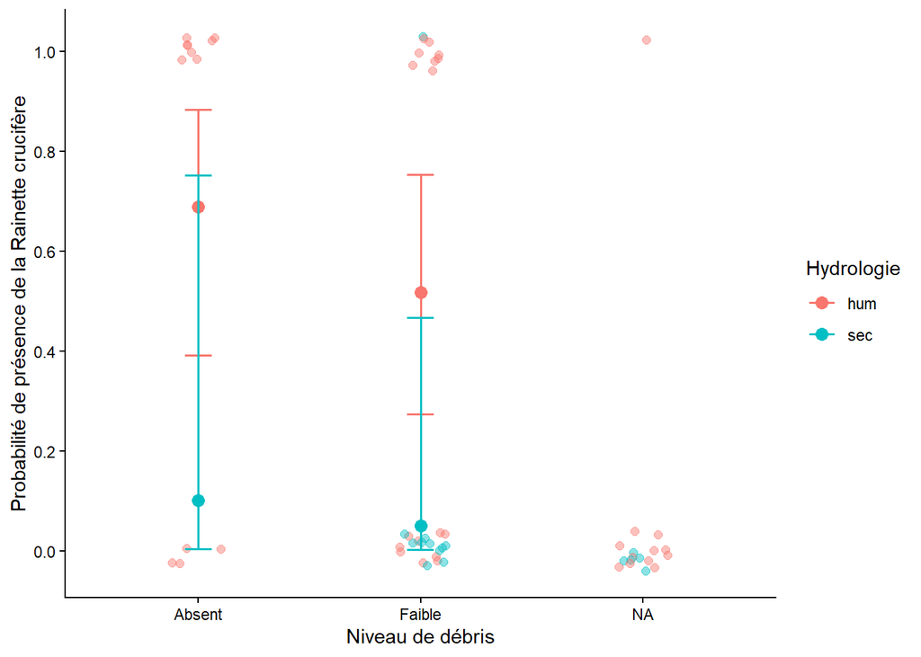

   ```r
   df$Debris_out <- factor(df$Debris_out,levels = c(1, 2, 3),labels = c("Absent", "Faible", "Élevé"))
   PSmod_hydro_deb <- glm(PSCR ~ Debris_out+Hydro+X+Y,family = binomial,data = df)

   pred_PSCR <- emmeans(PSmod_hydro_deb,~ Debris_out + Hydro,type = "response")
   pred_PSCR <- as.data.frame(pred_PSCR)

   ggplot() +
   geom_jitter(data = df,aes(x = Debris_out,y = PSCR,colour = Hydro),width = 0.12,height = 0.04,alpha = 0.45,size = 2) +
   geom_point(data = pred_PSCR,aes(x = Debris_out,y = prob,colour = Hydro), size = 3) +
   geom_errorbar(data = pred_PSCR,aes(x = Debris_out,ymin = asymp.LCL,ymax = asymp.UCL,colour = Hydro),width = 0.12,linewidth = 0.7) +
   scale_y_continuous(breaks = seq(0, 1, 0.2)) +
   labs(x = "Niveau de débris",y = "Probabilité de présence de la Rainette crucifère",colour = "Hydrologie") +
   theme_classic()
   ```

Voici la prédiction pour le modèle qui inclus l’ouverture de la canopée et l’hydropéridoe:

```r
pred_PSCR <- ggpredict(PSmod_can_hydro,terms = c("Ouverture", "Hydro"))
```

```
Data were 'prettified'. Consider using `terms="Ouverture [all]"` to get
  smooth plots.
```

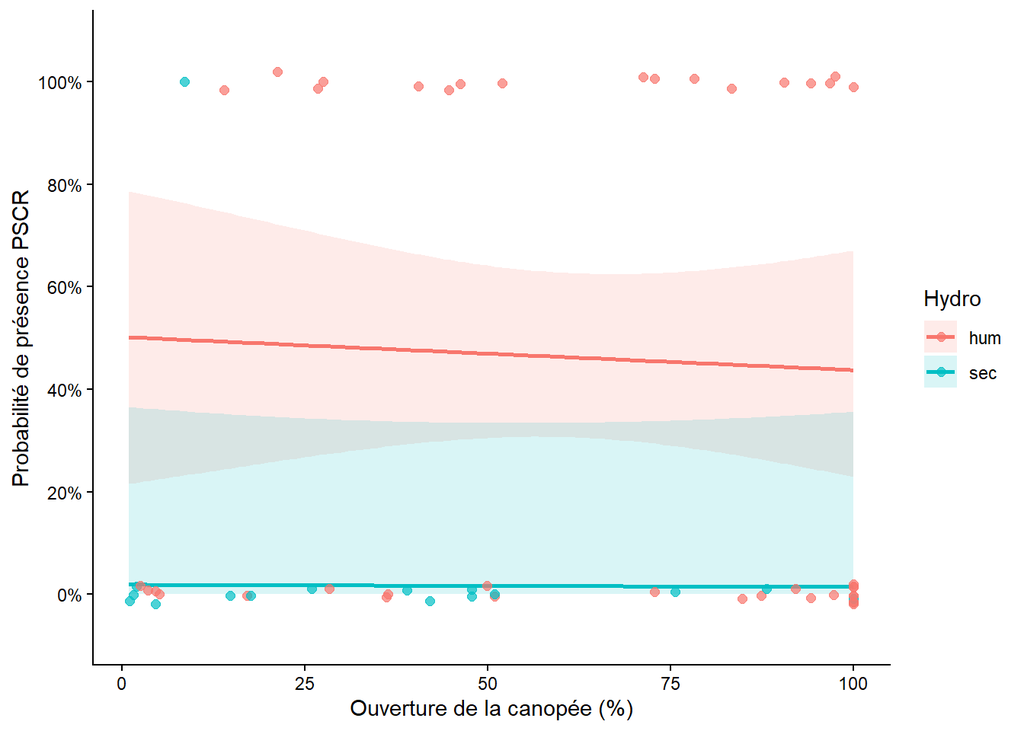

```r
set.seed(123)
ggplot(pred_PSCR, aes(x = x, y = predicted, colour = group)) +
  # Intervalle de confiance
  geom_ribbon(aes(ymin = conf.low, ymax = conf.high, fill = group),alpha = 0.15,colour = NA) +
  # Courbes prédites
  geom_line(linewidth = 1) +
  # Observations réelles
  geom_jitter(data = df,aes(x = Ouverture, y = PSCR, colour = Hydro),width = 0,height = 0.02,alpha = 0.7,size = 2) +
  scale_y_continuous(limits = c(-0.08, 1.08),breaks = seq(0, 1, 0.2),labels = function(x) paste0(x * 100, "%")) +
  labs(x = "Ouverture de la canopée (%)",y = "Probabilité de présence PSCR",colour = "Hydro",fill = "Hydro") +
  theme_classic()
```

Les rainettes semblent être plus présentes quand il y a moins de débris et une hydropériode plus longue.

## Conclusion de l’analyse des communautées d’amphibiens:

Les analyses précédentes ont permis de conclure que les communautés d’amphibiens diffèrent selon la présence ou l’absence de salamandres du genre Ambystoma. En effet, l’analyse IndVal indique que celles-ci sont des espèces indicatrices des traitements CJ et NAT. Ces traitements sylvicoles influencent les valeurs environnementales en créant des conditions qui sont liés à des étangs vernaux typiques. Ceci inclus une canopée plutôt fermée (prouvé de manière significative) et des étangs à hydropériode plus courtes (non prouvé de manière significative par manque de donnée, mais tendance claire). Une autre analyse indique aussi que ces deux valeurs environnementales sont les mécanismes les plus importants pour déterminer la présence des ambystomes.  
Ainsi, les communautés d’amphibiens qui se ressemblent sont celles qui se trouvent dans les traitements NAT et CJ alors que celles du PEH et CPPTM diffèrent puisqu’elles n’ont pas d’ambystomes. Les traitements PEH et CPPTM semblent être associés avec des milieux ouverts et des étangs qui ont une hydropériode plus longue.

Surprenament, la grenouille des bois, aussi dépendante des étangs vernaux, ne semble pas aussi sensible que les salamandres aux changements dans la canopée/hydropériode. Ceci pourrait être expliqué par leur capacité de déplacement plus développée. Toutefois, ceci pourrait aussi être lié à un biais d’échantillonage:  
J’ai choisi mes étangs lors de la ponte du printemps. Seulement les oeufs de LISY et d’ambystomes étaient visibles. Puisque les ambystomes ne semblent pas utiliser les plantations de PEH et les CPPTM, les étangs que choisis dans ces types de traitements contenaient obligatoirement des LISY. Puisqu’il y a beaucoup d’autres espèces dans ces habitats comme la LICL et la PSCR, si j’aurais pu voir leurs oeufs, j’aurais pu avoir la possibilité de choisir des étangs qui ne contenaient pas exclusivement que des LISY. Avec le biais de sélection présent, ça donne l’impression qu’il y a plein de LISY dans les PEH/CPPTM alors qu’ils pourraient être en fait moins commun que d’autres espèces plus cryptiques comme les LICL et PSCR. Surtout que la littérature associe les LISY avec des canopées plus fermées comparés aux autres espèces inventoriées (LICL et PSCR).

Un autre point à apporter c’est que les communautés dans les PEH et NAT ne sont pas similaires (manque de salamandres). Selon les analyses jusqu’à maintenant, les plantations ne semblent pas être un environnement adaptée pour les ambystomes et n’est pas du tout similaire au milieu naturel. Il a toutefois le potentiel de supporter des espèces avec une meilleure mobilités comme les anoures.